# Attendance Modeling

## Create a Linear Model to Fit the Data

### Test the Linear Model Assumptions

Test for Heteroscedasticity

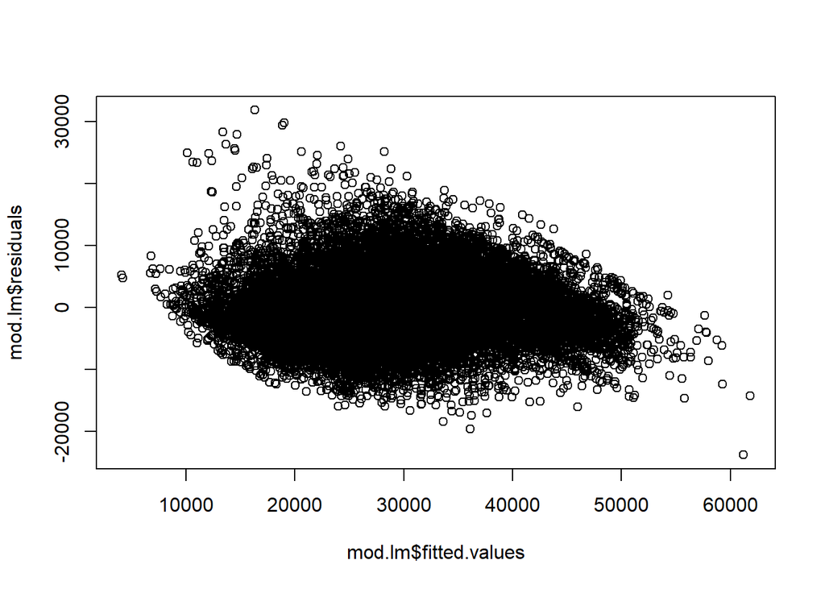

It appears that heteroscedasticity may be present

Run Stastistical test for heteroscedasticity

```
##
##  studentized Breusch-Pagan test
##
## data:  mod.lm
## BP = 1890, df = 92, p-value < 2.2e-16
```

It is definitely present

See if the response variable, attendance, can be transformed to eliminate heteroscedasticity

```
## Box-Cox Transformation
##
## 19036 data points used to estimate Lambda
##
## Input data summary:
##    Min. 1st Qu.  Median    Mean 3rd Qu.    Max.
##    5297   21772   30428   30049   38424   56432
##
## Largest/Smallest: 10.7
## Sample Skewness: -0.0968
##
## Estimated Lambda: 1
## With fudge factor, no transformation is applied
```

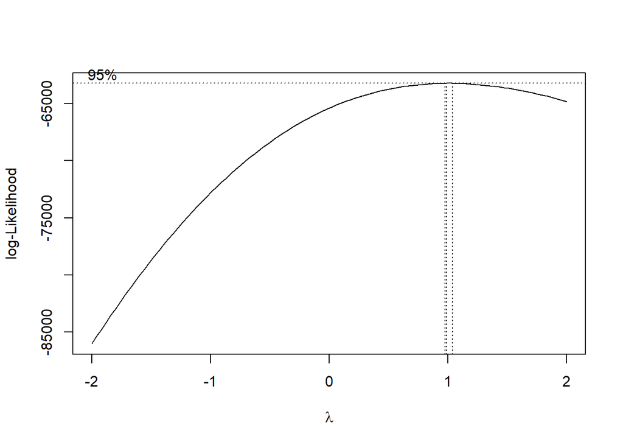

Lambda is 1, indicating that there is no easy modification to the response variable to eliminate heteroscedasticity

### Check for normally distributed errors

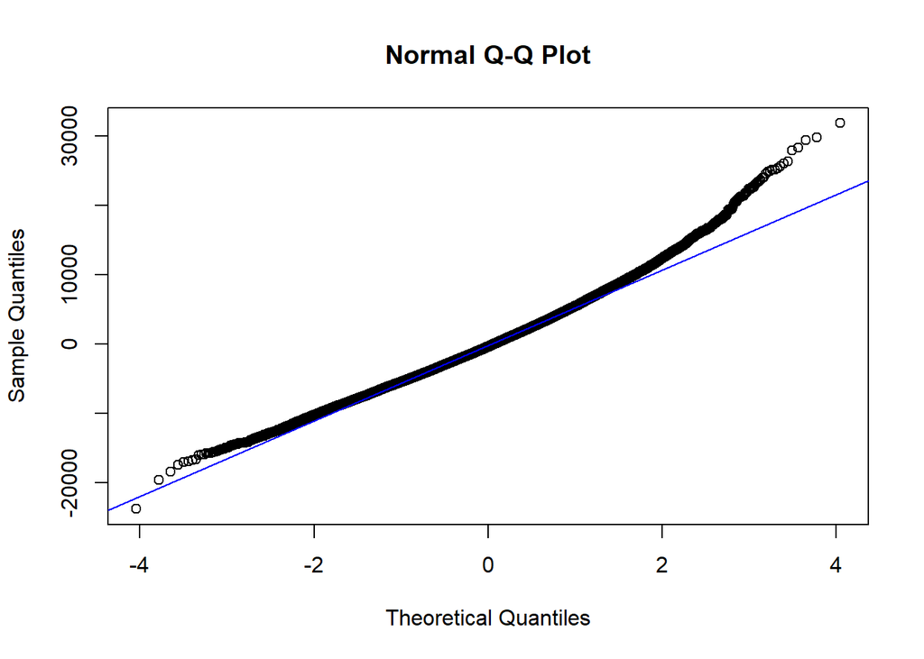

The errors are not normally distributed

### Check for correlation of errors

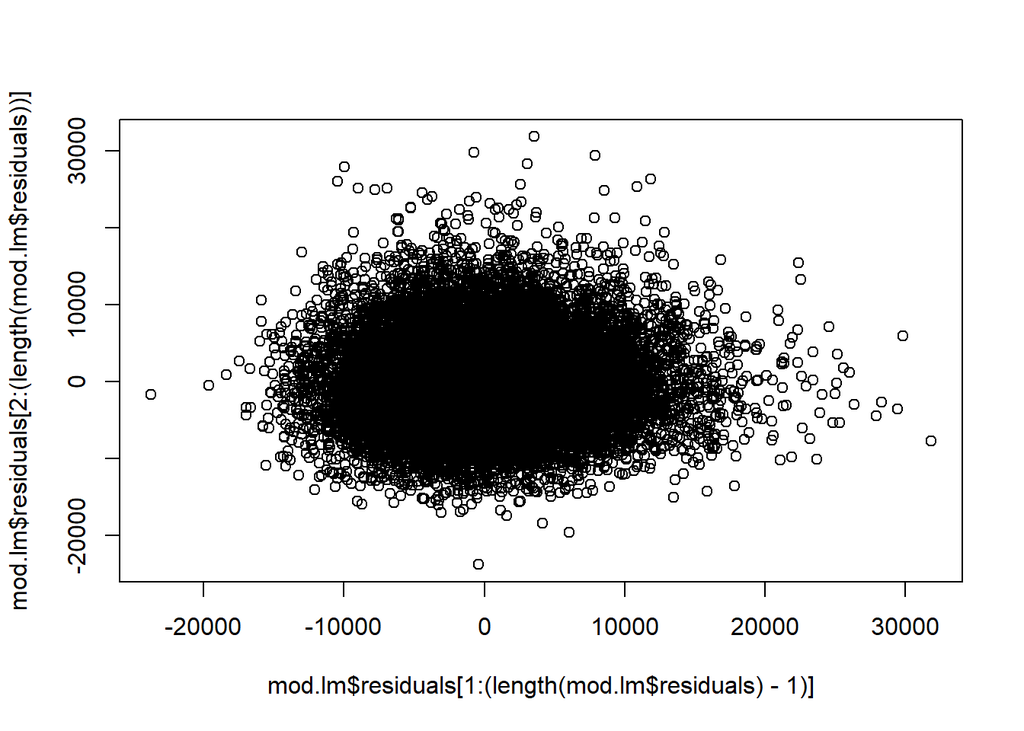

```
##
##  Durbin-Watson test
##
## data:  mod.lm
## DW = 1.9655, p-value = 0.008623
## alternative hypothesis: true autocorrelation is greater than 0
```

## Create and Tune a Random Forest Model

Initalize the model and test first parameters

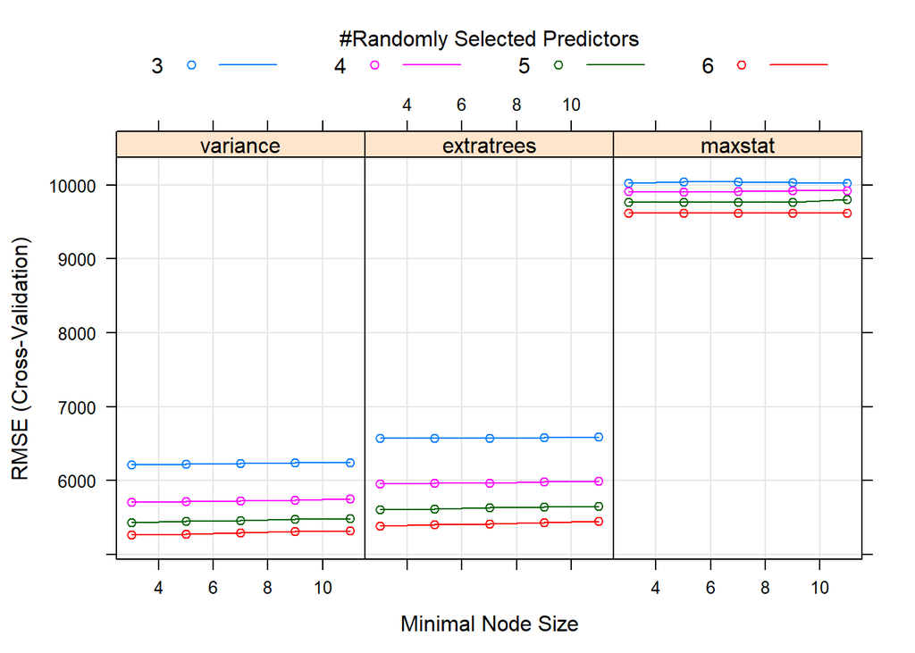

It appears best when min.node.size is 3, mtry is 6, and the split rule is variance

Further tune the model

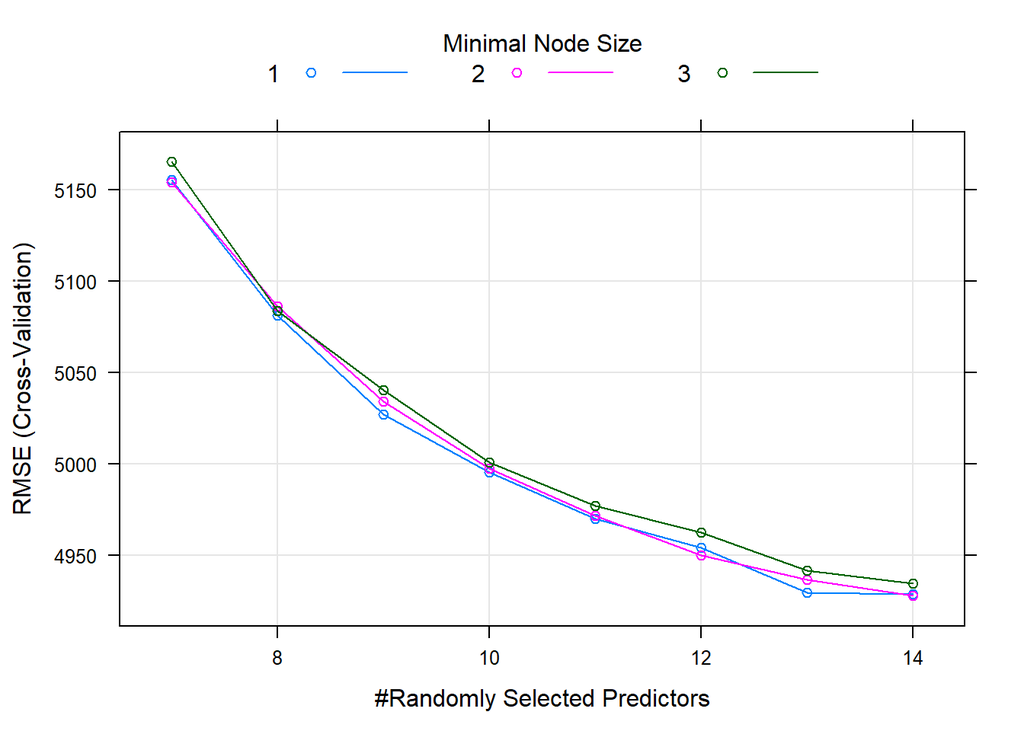

The optimal parameters are using an mtry of 14, splitrule of variance, and min node size of 2

## Create and Tune an XGBoost Linear Model

Find the optimal number for nrounds

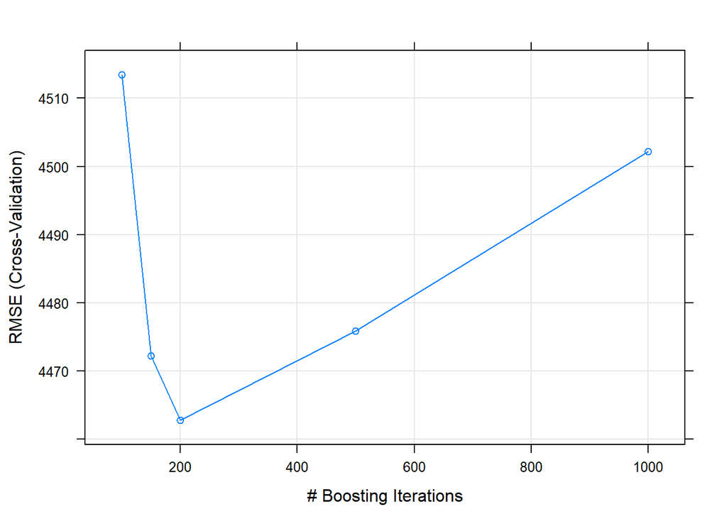

It looks like nrounds 200 is best

Fix nrounds and find optimal values for lambda and alpha

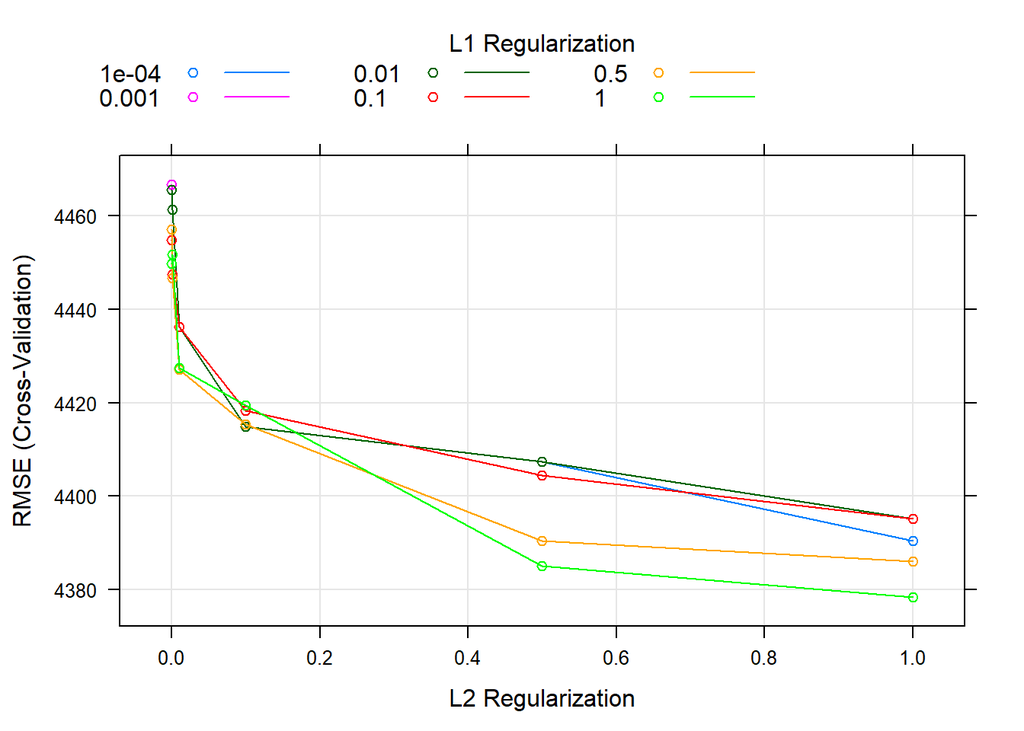

The best values for lambda and alpha both are 1

Find optimal eta value and search for a more prescise value for nrounds

```
## eXtreme Gradient Boosting
##
## 19036 samples
##    14 predictor
##
## No pre-processing
## Resampling: Cross-Validated (5 fold)
## Summary of sample sizes: 15229, 15230, 15229, 15228, 15228
## Resampling results across tuning parameters:
##
##   nrounds  eta   RMSE      Rsquared   MAE
##   100      0.01  4456.033  0.8123090  3349.363
##   100      0.10  4456.033  0.8123090  3349.363
##   100      0.30  4456.033  0.8123090  3349.363
##   100      0.50  4456.033  0.8123090  3349.363
```

[output cut: 99 more lines]

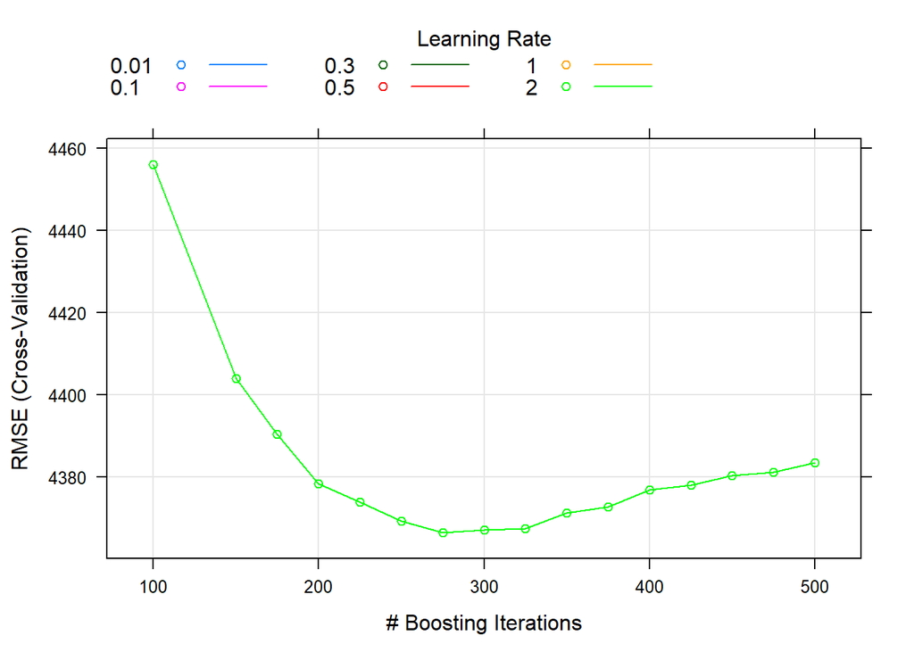

The final parameters for the XGBoost model is lambda = 1, alpha = 1, nrounds = 275, eta = .01

# Tune the XGBoost Model

(Step through each parameter individually due to processing time)

Find the optimal number of rounds

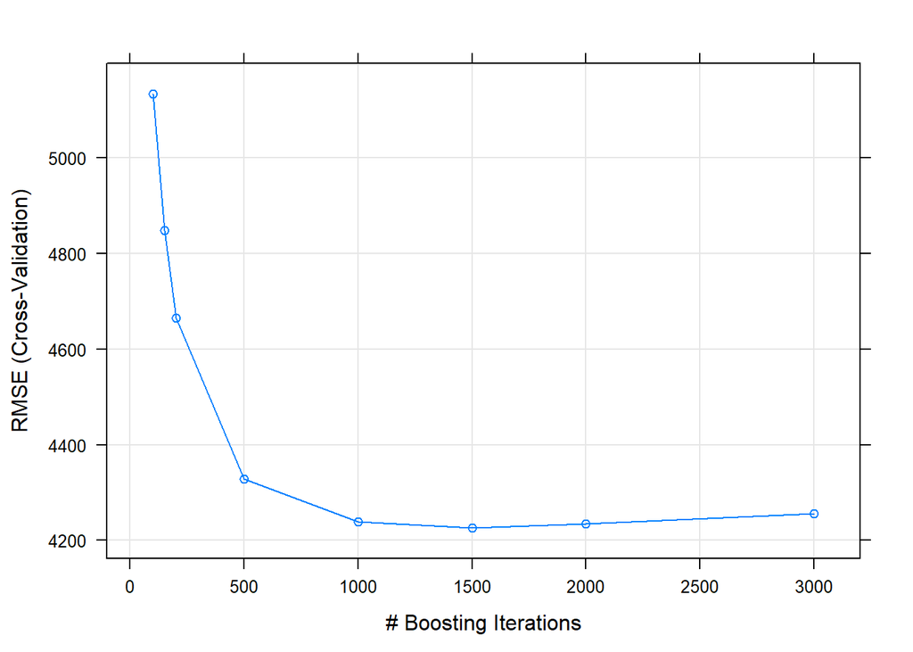

Optimal nrounds is 1500

Find the optimal value of max_depth, the maximum depth of each tree

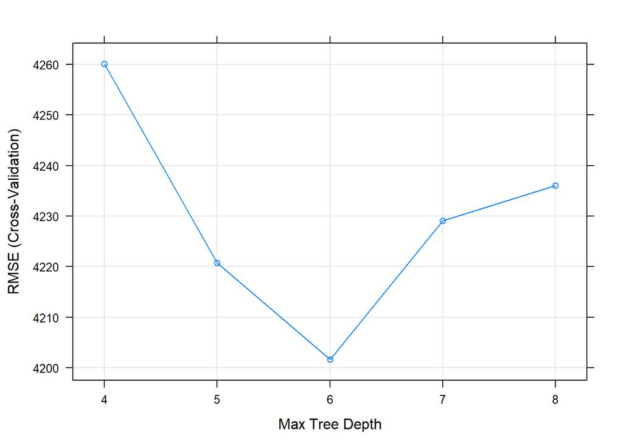

The optimal number for max tree depth is 6

Find the optimal value of min_child_weight, the threshold for stopping to try new nodes

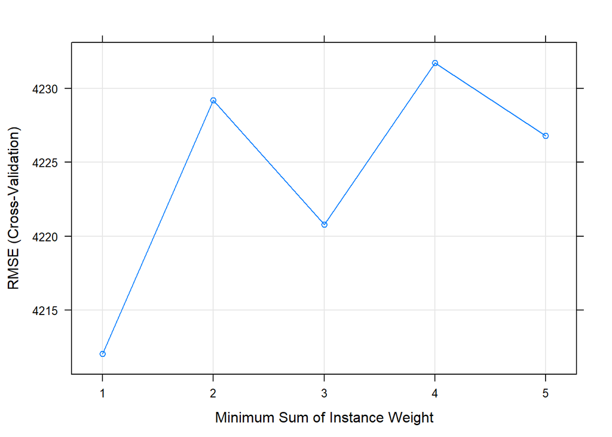

Optimal number for min child weight is 1

Tune subsample

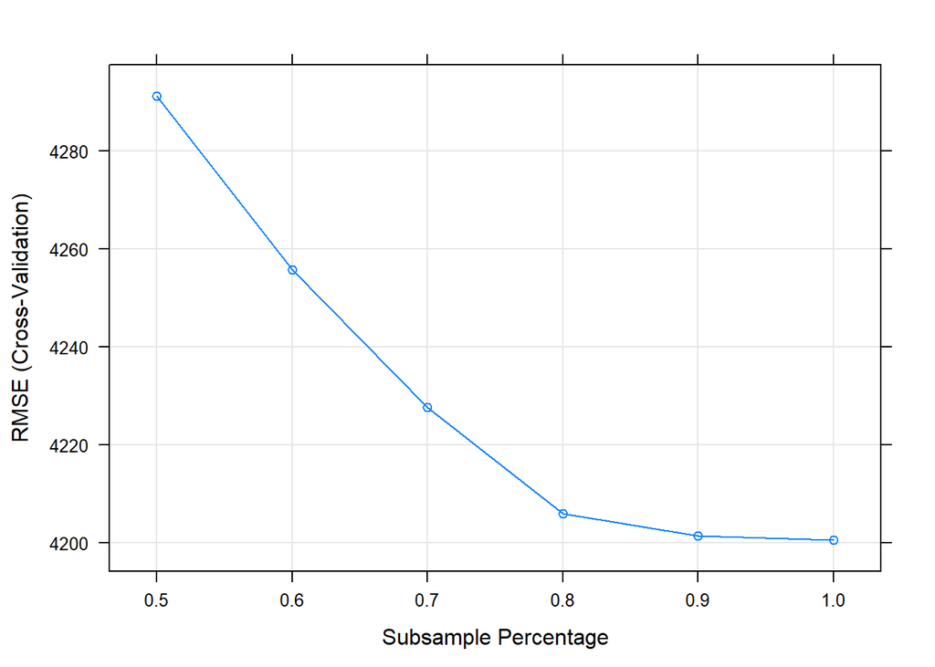

Optimal number for subsample is 1

Tune colsample_bytree

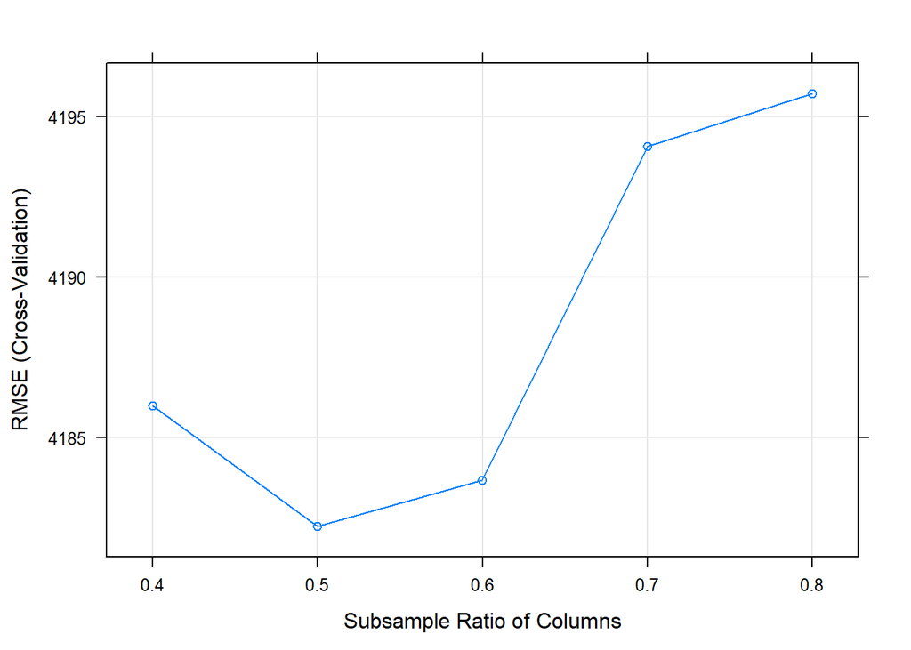

Optimal number for colsample by tree is .5

Tune gamma, minimum loss reduction required to makes further partitions on a leaf node

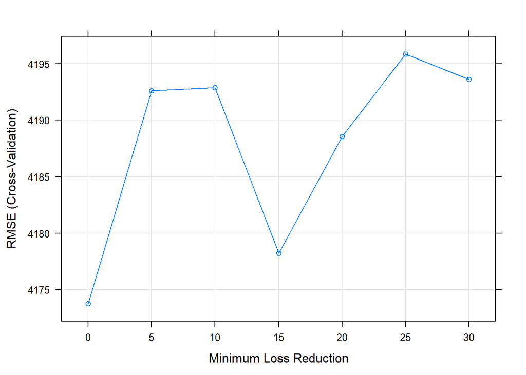

Optimal number for gamma is 0

Find optimal value for eta

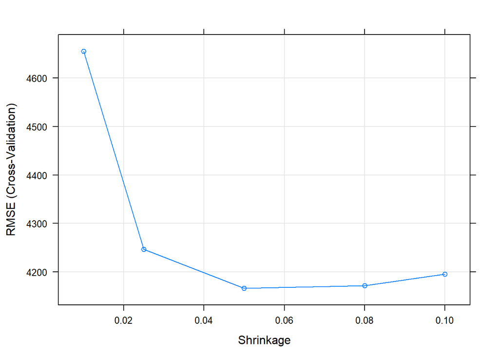

## Tune GLM Model

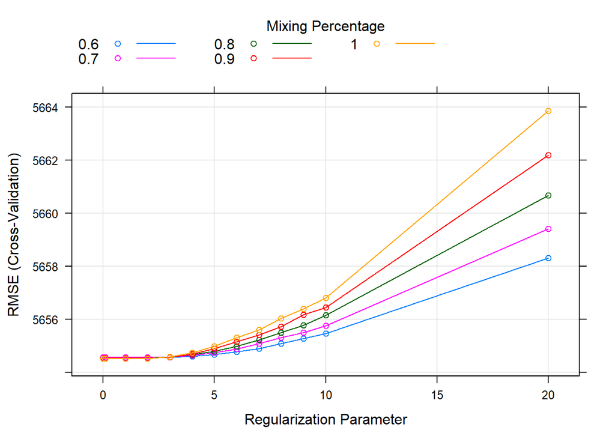

Optimal values for the GLM model is alpha = 1, lambda = 1